# Statistical analysis

```r
path_loc = "D:/Onedrive/SNCF/Analyses/sncf_memoire_analysis/results/"
setwd(path_loc)
options(scipen=999)
rm(path_loc)
```

# I. **Introduction**

This file is used to produce all the analyses performed to validate the **General flexibility Scale** (**Code R** : **nflex** = new flexibility). It contains script to describe the sample (age, sexe…), items of the **nflex** scale,the exploratory factorial analysis (using **polychoric correlation** and **principal axis factor analysis**) and the confirmatory factorial analysis used to assess the internal structure of the other scale (**polychoric correlations** and **diagonal weighted least square factor analysis**).  
A simulated dataset with same parameters is available at : https://github.com/Anghille/flexibility_memory_analysis

# II. **Setup**

## 1. **Loading librairies**

```r
wants <- c("psych","reshape","reshape2","car","carData","moments","tidyverse","stringr","plotly","readxl","ggthemes","GGally","grid","gridExtra","data.table","esquisse","Hmisc","psychTools", "stargazer","polycor","jtools","lavaan","lavaanPlot","corrplot","ggpubr")
has <- wants %in% rownames(installed.packages())
if(any(!has)) install.packages(wants[!has])
invisible(lapply(wants, library, character.only = TRUE))
rm(has, wants)
```

## 2. **Loading database**

```r
# Change path were your dataset is downloaded
path = "D:/Onedrive/SNCF/Analyses/sncf_memoire_analysis/results/DATA.csv"
data = read.csv2(file = path)
rm(path)
head(data)
```

|  | ï..sujet | Age | Sexe | Situation.professionnelle.avant.le.confinement | Langue.maternelle | Niveau.de.franÃ.ais | cognitive_rigidity_1 | cognitive_rigidity_2 | cognitive_rigidity_3 | cognitive_rigidity_4 | att_switch_1 | att_switch_2 | att_switch_3 | att_switch_4 | att_switch_5 | att_switch_6 | att_switch_7 | att_switch_8 | att_switch_9 | att_switch_10 | nflex_1 | nflex_2 | nflex_3 | nflex_4 | nflex_5 | nflex_6 | nflex_7 | nflex_8 | nflex_9 | … |
| --- | --- | --- | --- | --- | --- | --- | --- | --- | --- | --- | --- | --- | --- | --- | --- | --- | --- | --- | --- | --- | --- | --- | --- | --- | --- | --- | --- | --- | --- | --- |
| 1 | CS121996 | 23 | Femme | Etudiant | Français | ok | 2 | 6 | 5 | 6 | 2 | 4 | 4 | 4 | 2 | 4 | 4 | 3 | 4 | 3 | 5 | 3 | 4 | 4 | 5 | 4 | 4 | 6 | 3 | … |
| 2 | GS021998 | 22 | Homme | Travailleur | Français | ok | 3 | 3 | 1 | 5 | 3 | 2 | 3 | 2 | 3 | 2 | 4 | 3 | 2 | 1 | 5 | 6 | 2 | 5 | 6 | 6 | 5 | 5 | 4 | … |
| 3 | AN011980 | 26 | Homme | Etudiant | Français | ok | 4 | 3 | 3 | 3 | 2 | 3 | 2 | 3 | 2 | 3 | 2 | 3 | 3 | 2 | 4 | 5 | 3 | 4 | 5 | 5 | 4 | 4 | 3 | … |
| 4 | VP081998 | 21 | Homme | Etudiant | Français | ok | 3 | 2 | 5 | 4 | 1 | 2 | 2 | 1 | 4 | 3 | 3 | 4 | 1 | 1 | 4 | 4 | 1 | 4 | 3 | 4 | 2 | 4 | 2 | … |
| 5 | CM101998 | 21 | Femme | Etudiant | Français | ok | 3 | 5 | 3 | 5 | 3 | 2 | 4 | 2 | 4 | 4 | 3 | 4 | 3 | 2 | 6 | 6 | 3 | 5 | 3 | 5 | 4 | 5 | 5 | … |
| 6 | VD070997 | 22 | Homme | Etudiant | Français | ok | 4 | 3 | 3 | 3 | 3 | 1 | 1 | 2 | 2 | 2 | 2 | 2 | 2 | 3 | 4 | 4 | 3 | 4 | 5 | 3 | 4 | 4 | 4 | … |

## 3. **database cleaning**

```r
# Rename some variables
x = 0
a = c("Situation","Mothertongue","French level","Pourcentage")
for(i in c("Situation.professionnelle.avant.le.confinement","Langue.maternelle","Niveau.de.franÃ.ais","Pourcentage_perseveration_error_count")){
  x = x+1
  names(data)[names(data)==i] = a[x]
}

# set column name to lowerstring
data = setnames(data, tolower(names(data)))
data$pourcentage = as.numeric(data$pourcentage)
# Create all the needed dataframes
data_cleaned_scale = data %>% drop_na(c(7:42)) %>% filter(!(situation=="Sans emploi"))
data_cleaned_wcst = data %>% drop_na(c(7:48)) %>% filter(!(situation=="Sans emploi"))
nflex = data_cleaned_scale[,c(21:30)]
nflex_inv = nflex

# Invert item that are inverted in the scales
inverted_item_likert7 = c("cognitive_rigidity_1","att_switch_1","att_switch_2","att_switch_4","att_switch_9","att_switch_10","cfs_2","cfs_3","cfs_5","cfs_10","nflex_3","nflex_5","nflex_7","nflex_9")
inverted_item_likert4 = c("att_switch_1","att_switch_2","att_switch_4","att_switch_9","att_switch_10")
for(i in inverted_item_likert7){
    if(i %in% inverted_item_likert4){
      data_cleaned_scale[[i]] = 5-data_cleaned_scale[[i]]
    } else{
      data_cleaned_scale[[i]] = 7-data_cleaned_scale[[i]]
    }
}

# Initiate some variables needed for analysis
## Get number of observation
n_row = nrow(data_cleaned_scale)
rm(a, nflex, inverted_item_likert4, inverted_item_likert7, x)
```

**Note**. *We’ll be using nflex_inv for further analysis of the scale structure. We’ll be using data_cleaned_scale for the confirmatory factor analysis of the other scales.*

# III. **Descriptive statistics**

## 1. **Sample description**

```r
# Shows frequencies of variables
describe(data$situation)
```

```
## data$situation
##        n  missing distinct
##      387        0        3
##
## Value         Etudiant Sans emploi Travailleur
## Frequency          161          37         189
## Proportion       0.416       0.096       0.488
```

```r
describe(data$sexe)
```

```
## data$sexe
##        n  missing distinct
##      387        0        3
##
## Value      Autre Femme Homme
## Frequency      2   274   111
## Proportion 0.005 0.708 0.287
```

```r
# Affichage du tableau descriptif
stargazer(as.data.frame(data), type="text")
```

```
##
## =======================================================================
## Statistic             N   Mean  St. Dev.  Min  Pctl(25) Pctl(75)  Max
## -----------------------------------------------------------------------
## age                  387 32.990  14.773   18      22       43      84
## cognitive_rigidity_1 387 3.377   1.153     1      3        4       6
## cognitive_rigidity_2 387 3.494   1.203     1      3        4       6
## cognitive_rigidity_3 387 3.333   1.113     1      3        4       6
## cognitive_rigidity_4 387 3.729   1.021     1      3        4       6
## att_switch_1         387 2.638   0.719     1      2        3       4
## att_switch_2         387 2.514   0.847     1      2        3       4
## att_switch_3         387 2.894   0.850     1      2        3       4
## att_switch_4         387 2.687   0.918     1      2        3       4
## att_switch_5         387 2.775   0.915     1      2        3       4
## att_switch_6         387 2.881   0.793     1      2        3       4
## att_switch_7         387 3.078   0.788     1      3        4       4
## att_switch_8         387 3.065   0.778     1      3        4       4
## att_switch_9         387 2.855   0.922     1      2        4       4
## att_switch_10        387 2.566   0.945     1      2        3       4
## nflex_1              387 4.597   1.114     1      4        5       6
## nflex_2              387 4.491   0.991     1      4        5       6
## nflex_3              387 3.439   1.338     1      2        4       6
## nflex_4              387 4.566   1.037     1      4        5       6
## nflex_5              387 3.837   1.296     1      3        5       6
## nflex_6              387 4.406   1.182     1      4        5       6
## nflex_7              387 3.370   1.243     1      2        4       6
## nflex_8              387 4.258   1.129     1      4        5       6
## nflex_9              387 3.171   1.328     1      2        4       6
## nflex_10             387 4.576   1.113     1      4        5       6
## cfs_1                387 4.649   1.041     1      4        6       6
## cfs_2                387 2.842   1.250     1      2        4       6
## cfs_3                387 2.778   1.421     1      2        4       6
## cfs_4                387 4.119   1.006     1      4        5       6
## cfs_5                387 2.579   1.111     1      2        3       6
## cfs_6                387 4.755   1.007     2      4        6       6
## cfs_7                387 4.307   0.928     1      4        5       6
## cfs_8                387 4.209   1.108     1      4        5       6
## cfs_9                387 4.124   1.056     1      4        5       6
## cfs_10               387 2.674   1.214     1      2        3       6
## cfs_11               387 4.974   0.973     1      4        6       6
## cfs_12               387 3.835   1.250     1      3        5       6
## pourcentage          93  11.559  4.935   0.000  8.000    13.000  30.000
## -----------------------------------------------------------------------
```

**Sexe and Situation distribution function of age :**

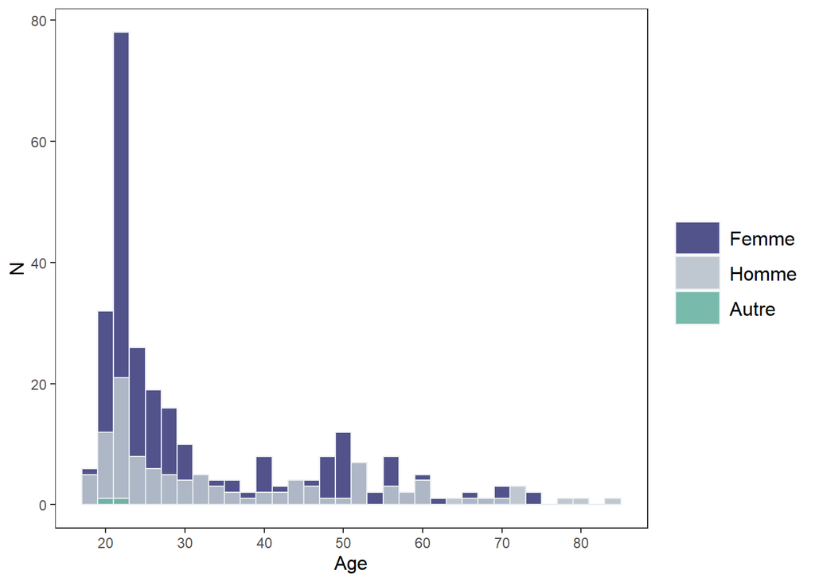

```r
# Subject's histogram

data_ggplot = data
data_ggplot$situation = factor(data_ggplot$situation, levels=c("Etudiant", "Travailleur", "Sans emploi"))
data_ggplot$sexe = factor(data_ggplot$sexe, levels=c("Femme", "Homme", "Autre"))

## For sexe/age
ggplot(data=data_ggplot, aes(x=age, fill=sexe)) +
  geom_histogram(color="#e9ecef", alpha=.9, position ="identity",binwidth = 2) +
  scale_fill_manual(values=c("#404080", "#b8c2cc", "#69b3a2")) +
  theme_apa() +
  theme(legend.position = "right") +
  labs(fill="Sexe") +
  scale_x_continuous(name="Age", breaks = seq(0, 85, 10)) +
  ylab("N")
```

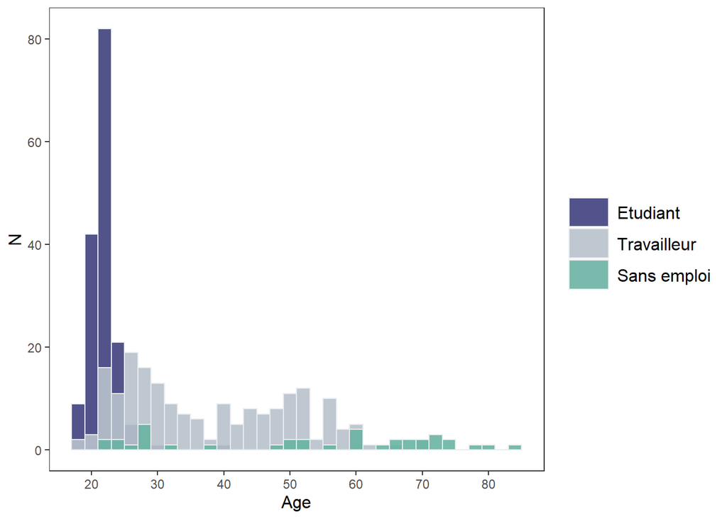

```r
## For situation/age
ggplot(data=data_ggplot, aes(x=age, fill=situation))+
  geom_histogram(color="#e9ecef", alpha=.9, position ="identity",binwidth = 2) +
  scale_fill_manual(values=c("#404080", "#b8c2cc", "#69b3a2")) +
  theme_apa() +
  theme(legend.position = "right") +
  ylab("N") +
  labs(fill="Situation") +
  scale_x_continuous(name="Age", breaks = seq(0, 85, 10))
```

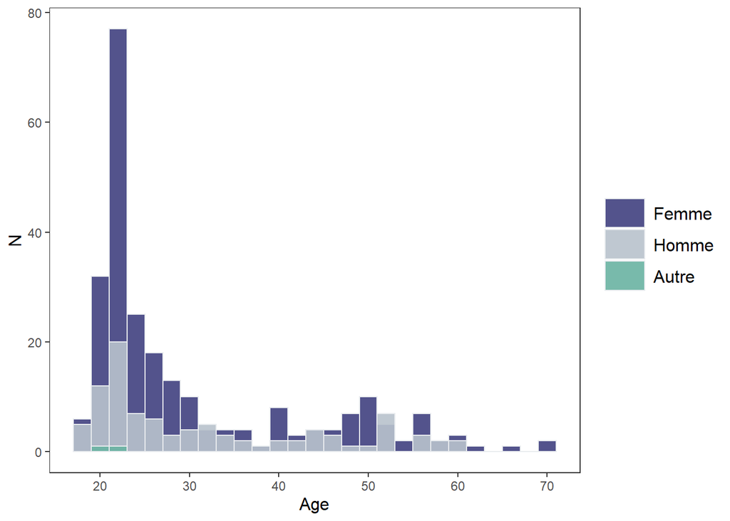

```r
data_ggplot = data_cleaned_scale
data_ggplot$situation = factor(data_ggplot$situation, levels=c("Etudiant", "Travailleur", "Sans emploi"))
data_ggplot$sexe = factor(data_ggplot$sexe, levels=c("Femme", "Homme", "Autre"))

## For sexe/age
ggplot(data=data_ggplot, aes(x=age, fill=sexe)) +
  geom_histogram(color="#e9ecef", alpha=.9, position ="identity",binwidth = 2) +
  scale_fill_manual(values=c("#404080", "#b8c2cc", "#69b3a2")) +
  theme_apa() +
  theme(legend.position = "right") +
  labs(fill="Sexe") +
  scale_x_continuous(name="Age", breaks = seq(0, 85, 10)) +
  ylab("N")
```

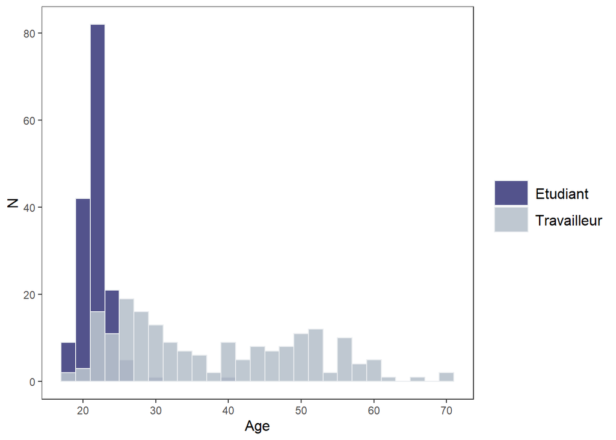

```r
## For situation/age
ggplot(data=data_ggplot, aes(x=age, fill=situation))+
  geom_histogram(color="#e9ecef", alpha=.9, position ="identity",binwidth = 2) +
  scale_fill_manual(values=c("#404080", "#b8c2cc", "#69b3a2")) +
  theme_apa() +
  theme(legend.position = "right") +
  ylab("N") +
  labs(fill="Situation") +
  scale_x_continuous(name="Age", breaks = seq(0, 85, 10))
```

```r
# All data set description with 350 subjects
stargazer(data_cleaned_scale, type="text")
```

```
##
## =======================================================================
## Statistic             N   Mean  St. Dev.  Min  Pctl(25) Pctl(75)  Max
## -----------------------------------------------------------------------
## age                  350 30.831  12.311   18      22      37.8     71
## cognitive_rigidity_1 350 3.580   1.167     1      3        4       6
## cognitive_rigidity_2 350 3.489   1.213     1      3        4       6
## cognitive_rigidity_3 350 3.303   1.112     1      3        4       6
## cognitive_rigidity_4 350 3.723   1.033     1      3        4       6
## att_switch_1         350 2.363   0.708     1      2        3       4
## att_switch_2         350 2.477   0.845     1      2        3       4
## att_switch_3         350 2.906   0.863     1      2       3.8      4
## att_switch_4         350 2.309   0.925     1      2        3       4
## att_switch_5         350 2.769   0.924     1      2        3       4
## att_switch_6         350 2.880   0.810     1      2        3       4
## att_switch_7         350 3.089   0.784     1      3        4       4
## att_switch_8         350 3.043   0.787     1      3        4       4
## att_switch_9         350 2.157   0.906     1      1        3       4
## att_switch_10        350 2.426   0.933     1      2        3       4
## nflex_1              350 4.583   1.106     1      4        5       6
## nflex_2              350 4.491   0.969     2      4        5       6
## nflex_3              350 3.471   1.319     1      3        4       6
## nflex_4              350 4.554   1.039     1      4        5       6
## nflex_5              350 3.134   1.301     1      2        4       6
## nflex_6              350 4.394   1.180     1      4        5       6
## nflex_7              350 3.637   1.245     1      3        5       6
## nflex_8              350 4.254   1.131     1      4        5       6
## nflex_9              350 3.829   1.335     1      3        5       6
## nflex_10             350 4.583   1.114     1      4        6       6
## cfs_1                350 4.660   1.052     1      4        6       6
## cfs_2                350 4.151   1.245     1      3        5       6
## cfs_3                350 4.197   1.405     1      3        5       6
## cfs_4                350 4.097   1.000     1      4        5       6
## cfs_5                350 4.414   1.098     1      4        5       6
## cfs_6                350 4.757   0.988     2      4        6       6
## cfs_7                350 4.331   0.930     1      4        5       6
## cfs_8                350 4.209   1.112     1      4        5       6
## cfs_9                350 4.157   1.055     1      4        5       6
## cfs_10               350 4.291   1.209     1      4        5       6
## cfs_11               350 4.980   0.982     1      4        6       6
## cfs_12               350 3.831   1.240     1      3        5       6
## pourcentage          87  11.494  4.969   0.000  8.000    13.000  30.000
## -----------------------------------------------------------------------
```

```r
# Sample Age description
statss = data_cleaned_scale %>%
  group_by(sexe, situation) %>%
  summarise(mean_age = mean(age), sd_age = sd(age))
# v = c(3,4,6,7)
# for(i in 1:4){
#   statss[v[i], 1]=NA
# }
stargazer(as.data.frame(statss), type="text", summary = F, digits = 2)
```

```
##
## ===================================
##   sexe   situation  mean_age sd_age
## -----------------------------------
## 1 Autre  Etudiant    21.50    0.71
## 2 Femme  Etudiant    22.21    2.30
## 3 Femme Travailleur  38.04   12.77
## 4 Homme  Etudiant    22.35    2.36
## 5 Homme Travailleur  38.41   12.44
## -----------------------------------
```

```r
rm(v, statss)
describe(data_cleaned_scale$situation)
```

```
## data_cleaned_scale$situation
##        n  missing distinct
##      350        0        2
##
## Value         Etudiant Travailleur
## Frequency          161         189
## Proportion        0.46        0.54
```

```r
describe(data_cleaned_scale$sexe)
```

```
## data_cleaned_scale$sexe
##        n  missing distinct
##      350        0        3
##
## Value      Autre Femme Homme
## Frequency      2   253    95
## Proportion 0.006 0.723 0.271
```

## 2. **General Cognitive Flexibility Scale**

### a. *Histograms*

Shows histogram for each item of the general cognitive flexibility scale. The goal is to check if any item seems to have an odd distribution, which would indicate that he isn’t suited to measure our flexibility. We therefore check item for **ceiling** or **skewed** items.

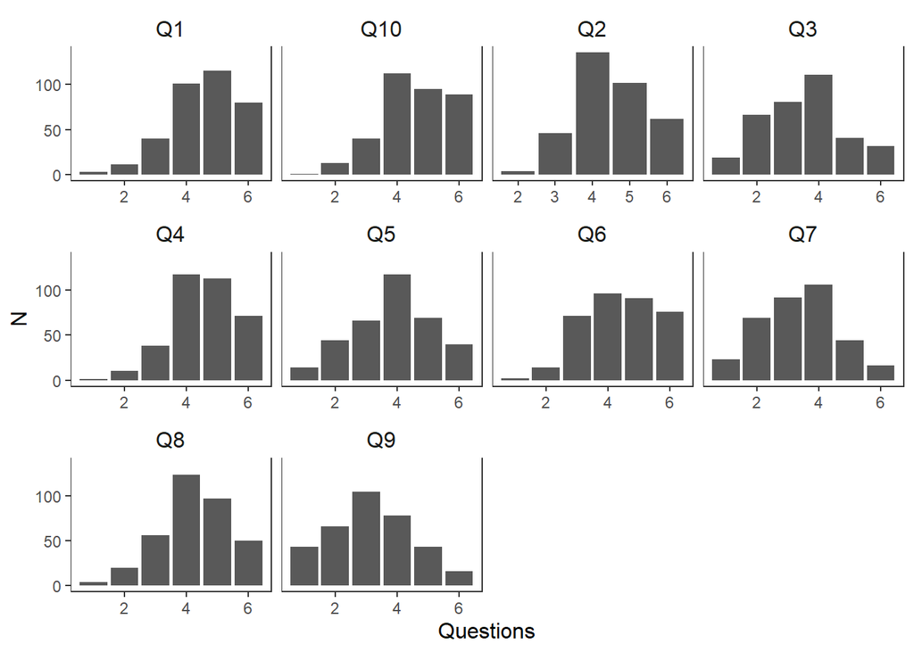

```r
# Shows the general flexibility items' histograms
ggplot_data = nflex_inv
ggplot_data = ggplot_data %>%
  rename(Q1 = nflex_1,
         Q2 = nflex_2,
         Q3 = nflex_3,
         Q4 = nflex_4,
         Q5 = nflex_5,
         Q6 = nflex_6,
         Q7 = nflex_7,
         Q8 = nflex_8,
         Q9 = nflex_9,
         Q10 = nflex_10)
ggplot(gather(ggplot_data), aes(x=value)) +
  geom_histogram(stat = "count") + facet_wrap(~key, scales = 'free_x') +
  scale_color_grey() +
  theme_apa() +
  theme(legend.position = "bottom") +
  xlab("Questions") + ylab("N")
```

**Items 1, 4, 6, 10** seems to have *ceiling* or *skewed* distribution. It is then recommended to check if **extreme values** of each item (values 1 and 6) have more than 20% of the responses. We therefore check for *skewness* and *kurtosis*. (Garin, 2014 ; Benzina, 2019)
**Reminder** :
The skewness coefficient is a third-order measure of the central tendency of the sample. A negative coefficient translate to a biased distribution toward the right. A positive coefficient translate to a biased distribution toward the left.
$$\gamma_{X} = E\left[\left(\frac{X - \mu}{\sigma}\right)^3\right]$$
The kurtosis coefficient is a 4th order measure of the central tendency of the sample. It translate to how fast the distribution goes back to 0 (if it does). Therefore, it shows if there is more extreme values than it should. A high kurtosis translate to high number of extreme values.
$$Kurt[X] = E\left[\left(\frac{X - \mu}{\sigma}\right)^4\right]$$

```r
item = colnames(nflex_inv)
kurt_skew = as.tibble(round(skewness(nflex_inv), 2)) %>%
  mutate(kurtosis = round(kurtosis(nflex_inv), 2)) %>%
  cbind(item) %>%
  rename(skewness = value)
rm(item)
kurt_skew[, c(3,1,2)]
```

| item | skewness | kurtosis |
| --- | --- | --- |
| nflex_1 | -0.57 | 3.02 |
| nflex_2 | -0.01 | 2.34 |
| nflex_3 | 0.09 | 2.41 |
| nflex_4 | -0.38 | 2.80 |
| nflex_5 | -0.22 | 2.47 |
| nflex_6 | -0.23 | 2.25 |
| nflex_7 | 0.05 | 2.47 |
| nflex_8 | -0.34 | 2.81 |
| nflex_9 | 0.15 | 2.37 |
| nflex_10 | -0.40 | 2.55 |

*References*

Benzina, N. (2019). Évaluation de la flexibilité cognitive dans le trouble obsessionnel compulsif : Étude de la validité de deux auto-questionnaires comparés à une tâche expérimentale. Université de Rouen.

The **table below** shows items with more than 20% of extreme values.

```r
# This script check what item got more than 20% of response in the extreme values. It then create a new dataframe containing only the items non extreme.

## Create dataframe with upper item and lower item frequencies of response
frequencies  = data.frame(item = character(10), upper = numeric(10), lower = numeric(10))
for(i in 1:10){
  upper = length(which(nflex_inv[i]==6))/n_row
  lower = length(which(nflex_inv[i]==1))/n_row
  frequencies$item[i] = paste0("nflex_", as.character(i))
  frequencies$upper[i] = upper
  frequencies$lower[i] = lower
}
frequencies
```

| item | upper | lower |
| --- | --- | --- |
| nflex_1 | 0.22857143 | 0.008571429 |
| nflex_2 | 0.17714286 | 0.000000000 |
| nflex_3 | 0.09142857 | 0.054285714 |
| nflex_4 | 0.20285714 | 0.002857143 |
| nflex_5 | 0.11428571 | 0.040000000 |
| nflex_6 | 0.21714286 | 0.005714286 |
| nflex_7 | 0.04571429 | 0.065714286 |
| nflex_8 | 0.14285714 | 0.011428571 |
| nflex_9 | 0.04571429 | 0.122857143 |
| nflex_10 | 0.25428571 | 0.002857143 |

```r
rm(upper, lower, i)

## Create a list used to delete item that have >.20 extreme values.
list = c()
for(i in 1:10){
  if(frequencies[i,2]>.20 | frequencies[i,3]>.20 ){
    list = c(list, i)
    }
}
# Create a dataframe with the remaining items of the General Cognitive Flexibility (GCF)
nflex_inv_reduct = nflex_inv[,-list]
```

### b. *Summary*

Items 1, 4, 6, 10 are in fact not well suited. We deleted them from further analysis.The next table shows the flexibiliy descriptive stats for the remaining items

```r
# Shows descriptive statistique for remaining items of the GCF
stargazer(as.data.frame(nflex_inv_reduct), type="text")
```

```
##
## ======================================================
## Statistic  N  Mean  St. Dev. Min Pctl(25) Pctl(75) Max
## ------------------------------------------------------
## nflex_2   350 4.491  0.969    2     4        5      6
## nflex_3   350 3.529  1.319    1     3        4      6
## nflex_5   350 3.866  1.301    1     3        5      6
## nflex_7   350 3.363  1.245    1     2        4      6
## nflex_8   350 4.254  1.131    1     4        5      6
## nflex_9   350 3.171  1.335    1     2        4      6
## ------------------------------------------------------
```

### c. *correlation*

We show here the item’s correlation. We used **polychoric correlation** as it is suited for ordinal values with skewed distribution. The polychoric correlation is a measure of the pairwise association of ordinal variables. We smooth the correlation to avoid any non positive definite measure (Debelak et Tran, 2016)  
*Références*

Debelak, R., & Tran, U. S. (2016). Comparing the Effects of Different Smoothing Algorithms on the Assessment of Dimensionality of Ordered Categorical Items with Parallel Analysis. *PloS one, 11(2)*, e0148143. https://doi.org/10.1371/journal.pone.0148143

D.L. Knol and JMF ten Berge (1989) Least squares approximation of an improper correlation matrix by a proper one. *Psychometrika, 54*, 53-61.

```r
# Compute the polychoric correlation (rho), smooth it by eigenvalue decomposition
poly_nflex_inv_reduct = polychoric(nflex_inv_reduct)
poly_nflex_inv_reduct = poly_nflex_inv_reduct$rho
poly_nflex_inv_reduct = cor.smooth(poly_nflex_inv_reduct, eig.tol=10^-12)
```

```r
# Shows correlation in a matrix
correlation = poly_nflex_inv_reduct
correlation[upper.tri(correlation)] <- NA
stargazer(correlation, title="Polychloric correlation matrix", type="text")
```

```
##
## Polychloric correlation matrix
## =======================================================
##         nflex_2 nflex_3 nflex_5 nflex_7 nflex_8 nflex_9
## -------------------------------------------------------
## nflex_2    1
## nflex_3 -0.220     1
## nflex_5 -0.164   0.243     1
## nflex_7 -0.279   0.308   0.280     1
## nflex_8  0.216  -0.034   0.047  -0.153     1
## nflex_9 -0.056   0.145   0.084   0.419  -0.104     1
## -------------------------------------------------------
```

```r
rm(correlation)
```

# IV. **Exploratory Factorial Analysis**

## 1. **EFA’s assumption**

```r
# Compute bartlett, KMO and check if we got an identity matrix
cortest.bartlett(R = poly_nflex_inv_reduct, n = n_row)
```

```
## $chisq
## [1] 205.5948
##
## $p.value
## [1] 0.00000000000000000000000000000000001546962
##
## $df
## [1] 15
```

```r
KMO(poly_nflex_inv_reduct)
```

```
## Kaiser-Meyer-Olkin factor adequacy
## Call: KMO(r = poly_nflex_inv_reduct)
## Overall MSA =  0.63
## MSA for each item =
## nflex_2 nflex_3 nflex_5 nflex_7 nflex_8 nflex_9
##    0.65    0.73    0.66    0.61    0.57    0.57
```

```r
det(poly_nflex_inv_reduct)
```

```
## [1] 0.5521594
```

**KMO’s measure of sample adequacy test**

$$MSA_{nflex} = .63 \space (MSA_{min} = .50)$$

**Bartlett Sphericity test**

*EFA is appropriate.*

**Det(cor(A))**

$$det(A) = 0.55,\space non-identity\space matrix$$
As shown byt the KMO test, items 8 and 9 seems to have a really low KMO. We therefore deleted them from further analysis, computed the polychoric correlation of this new dataset and tested again the assumptions :

```r
# Compute new dataset of nflex without item 8 and 9
nflex_inv_reduct_msa = nflex_inv_reduct[,-c(5,6)]

#Compute polychoric correlation with the item 8 and 9 removed
poly_nflex_inv_reduct_msa = polychoric(nflex_inv_reduct_msa)
poly_nflex_inv_reduct_msa = poly_nflex_inv_reduct_msa$rho
poly_nflex_inv_reduct_msa = cor.smooth(poly_nflex_inv_reduct_msa, eig.tol=10^-12)

# Compute bartlett, KMO and check if we got an identity matrix
cortest.bartlett(R = poly_nflex_inv_reduct_msa, n = n_row)
```

```
## $chisq
## [1] 110.5166
##
## $p.value
## [1] 0.000000000000000000001588907
##
## $df
## [1] 6
```

```r
KMO(poly_nflex_inv_reduct_msa)
```

```
## Kaiser-Meyer-Olkin factor adequacy
## Call: KMO(r = poly_nflex_inv_reduct_msa)
## Overall MSA =  0.68
## MSA for each item =
## nflex_2 nflex_3 nflex_5 nflex_7
##    0.70    0.69    0.70    0.65
```

```r
det(poly_nflex_inv_reduct_msa)
```

```
## [1] 0.7271338
```

**KMO’s measure of sample adequacy test**

$$MSA_{nflex} = .68 \space (MSA_{min} = .50)$$

**Bartlett Sphericity test**

$$\chi^2(6) = 110.51,\space p < .001.$$

*EFA is appropriate.*

**Det(cor(A))**

$$det(A) = 0.73,\space non-identity\space matrix$$
We need to test if it’s recommanded and possible to do an EFA. The **Bartlett Sphericity Test** compare our data matrix with matrix randomly generated by those same date and then check if those data are linked. The **measure sample adequacy test** of Kaiser-Meyer and Olin check sample adequacy for each variable in the model and for the complete.
**Reminder** : *Common variance* (variance shared between an item and other items), *specific variance* (variance of the item that isnt shared with other items) et *residual variance* (error associated to the item)
**Reminder 2** : Because we have ordinal data, we need to use the **polychoric correlation matrix** in the KMO and Bartlett tests and not the raw dataset, otherwise it will automatically use the **pearson correlation matrix** ! **Reminder 3** : MSA rise as sample size rise, mean correlation rise, number of variables rise et land number of factors drops. We used the modified MSA (Kaiser et Rice, 1974).

*Références*

Kaiser, H. F., & Rice, J. (1974). Little Jiffy, Mark Iv. *Educational and Psychological Measurement, 34(1)*, 111‑117. https://doi.org/10.1177/001316447403400115

Voir pour Bartlett Pour le déterminer, c’est inhérant aux méthodes d’analyse (pas de matrice identitaire, sans quoi, on ne peut pas calculer les matrices inverses)

Tinsley, H. E. A., & Tinsley, D. J. (1987). Uses of factor analysis in counseling psychology research. *Journal of Counseling Psychology, 34(4)*, 414‑424. https://doi.org/0022-0167.34.4.414

## 2. **Polychoric exploratory factorial analysis**

We used the **parallel analysis with polychoric correlation** because we have ordinal data, skewed items and non normality :

*Référence*

Buja, A., & Eyuboglu, N. (1992). Remarks on Parallel Analysis. *Multivariate Behavioral Research, 27(4)*, 509-540. http://doi.org/10.1207/s15327906mbr2704_2

Devlin, S. J., Gnanadesikan, R., & Kettenring, J. R. (1981). Robust estimation of dispersion matrices and principal components. *Journal of the American Statistical Association, 76*, 354-362. http://doi.org/10.1080/01621459.1981.10477654

ten Berge, J. M. F., & Kiers, H. A. L. (1991). A numerical approach to the approximate and the exact minimum rank of a covariance matrix. *Psychometrika, 56(2)*, 309-315. http://doi.org/10.1007/BF02294464

Timmerman, M. E., & Lorenzo-Seva, U. (2011). Dimensionality assessment of ordered polytomous items with parallel analysis. *Psychological Methods, 16(2)*, 209-220. http://doi.org/10.1037/a0023353

Ford, J. Kevin, Robert C. MacCALLUM, et Marianne Tait. « The Application of Exploratory Factor Analysis in Applied Psychology: A Critical Review and Analysis ». *Personnel Psychology 39, nᵒ 2* (juin 1986): 291‑314. https://doi.org/10.1111/j.1744-6570.1986.tb00583.x. (critère du 0.40)

Garrido, L. E., Abad, F. J., & Ponsoda, V. (2013). A new look at Horn’s parallel analysis with ordinal variables. *Psychological Methods, 18(4)*, 454‑474. PubMed. https://doi.org/10.1037/a0030005

Tinsley, H. E. A., & Tinsley, D. J. (1987). Uses of factor analysis in counseling psychology research. *Journal of Counseling Psychology, 34(4)*, 414‑424. https://doi.org/0022-0167.34.4.414  
We then used the efa wiith **least squares algorithm** (*principal axis factor analysis*), with number of factor indicated by the parallel analysis, and a varimax rotation. We set the factor loadings limit to .30 (Peterson, 2000). Anything below is considered too small.  
*Référence*

Ford, J. K., MacCALLUM, R. C., & Tait, M. (1986). The application of exploratory factor analysis in applied psychology : A critical review and analysis. *Personnel Psychology, 39(2)*, 291‑314. https://doi.org/10.1111/j.1744-6570.1986.tb00583.x

Lee, S.-Y., Poon, W.-Y., & Bentler, P. M. (1995). A two-stage estimation of structural equation models with continuous and polytomous variables. *British Journal of Mathematical and Statistical Psychology, 48(2)*, 339‑358. https://doi.org/10.1111/j.2044-8317.1995.tb01067.x

Baglin, J. (2014). Improving Your Exploratory Factor Analysis for Ordinal Data : A Demonstration Using FACTOR. *Practical Assessment, Research, and Evaluation*, 19(5), 1‑16. https://doi.org/10.7275/dsep-4220

Peterson, R. A. (2000). A Meta-Analysis of Variance Accounted for and Factor Loadings in Exploratory Factor Analysis. *Marketing Letters, 11(3)*, 261‑275.

Tinsley, H. E. A., & Tinsley, D. J. (1987). Uses of factor analysis in counseling psychology research. *Journal of Counseling Psychology, 34(4)*, 414‑424. https://doi.org/0022-0167.34.4.414\

```r
ConditionRegression <- function(model, df){
  #Installation des packages si non présent

  # List of packages for session
  .packages = c("tidyverse", "mediation", "stringr", "jtools", "psych", "lme4", "compare", "car", "carData", "apaTables", "reshape", "reshape2", "lindia", "gvlma")

  # Install CRAN packages (if not already installed)
  .inst <- .packages %in% installed.packages()
  if(length(.packages[!.inst]) > 0) install.packages(.packages[!.inst])

  # Load packages into session
  lapply(.packages, require, character.only=TRUE)


  #Fonction
  monModel <- model
  # apaT <- apa.reg.table(fit, prop.var.conf.level = 0.95)


  #Outliers
  gvmodel <- gvlma(monModel)
  plot(gvmodel)
  summary(gvmodel)
  summary(deletion.gvlma(gvmodel))
  plot(deletion.gvlma(gvmodel))
  ggDiagnose <- gg_diagnose(monModel, scale.factor = 1, max.per.page = 1)


}
```

```r
# Détermination des communalités initiales pour l'AFE à partir des R² des régressions multiples
lm1 = lm(nflex_2~nflex_3+nflex_5+nflex_7, data=nflex_inv_reduct_msa)
ConditionRegression(lm1)
```

[output not shown]

[figure not shown]

```
##
## Call:
## lm(formula = nflex_2 ~ nflex_3 + nflex_5 + nflex_7, data = nflex_inv_reduct_msa)
##
## Residuals:
##      Min       1Q   Median       3Q      Max
## -2.43239 -0.63096 -0.05088  0.66561  1.98528
##
## Coefficients:
##             Estimate Std. Error t value             Pr(>|t|)
## (Intercept)  5.61897    0.20002  28.092 < 0.0000000000000002 ***
## nflex_3     -0.09947    0.03979  -2.500             0.012888 *
## nflex_5     -0.06184    0.03995  -1.548             0.122527
## nflex_7     -0.15984    0.04251  -3.760             0.000199 ***
## ---
## Signif. codes:  0 '***' 0.001 '**' 0.01 '*' 0.05 '.' 0.1 ' ' 1
##
## Residual standard error: 0.924 on 346 degrees of freedom
## Multiple R-squared:  0.09796,    Adjusted R-squared:  0.09013
## F-statistic: 12.52 on 3 and 346 DF,  p-value: 0.00000008579
##
##
## ASSESSMENT OF THE LINEAR MODEL ASSUMPTIONS
## USING THE GLOBAL TEST ON 4 DEGREES-OF-FREEDOM:
## Level of Significance =  0.05
##
## Call:
##  gvlma(x = monModel)
##
##                       Value p-value                Decision
## Global Stat        4.319946 0.36443 Assumptions acceptable.
## Skewness           0.001554 0.96856 Assumptions acceptable.
## Kurtosis           3.417582 0.06451 Assumptions acceptable.
## Link Function      0.671723 0.41245 Assumptions acceptable.
## Heteroscedasticity 0.229088 0.63220 Assumptions acceptable.
##
## Global test deletion statistics.
##
## Linear Model:
##  lm(formula = nflex_2 ~ nflex_3 + nflex_5 + nflex_7, data = nflex_inv_reduct_msa)
```

[output cut: 71 more lines]

[output not shown]

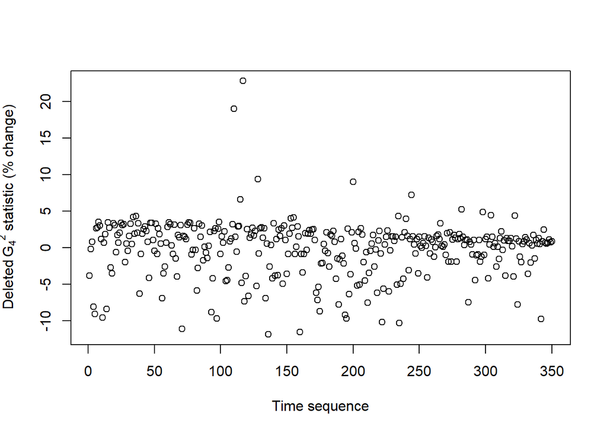

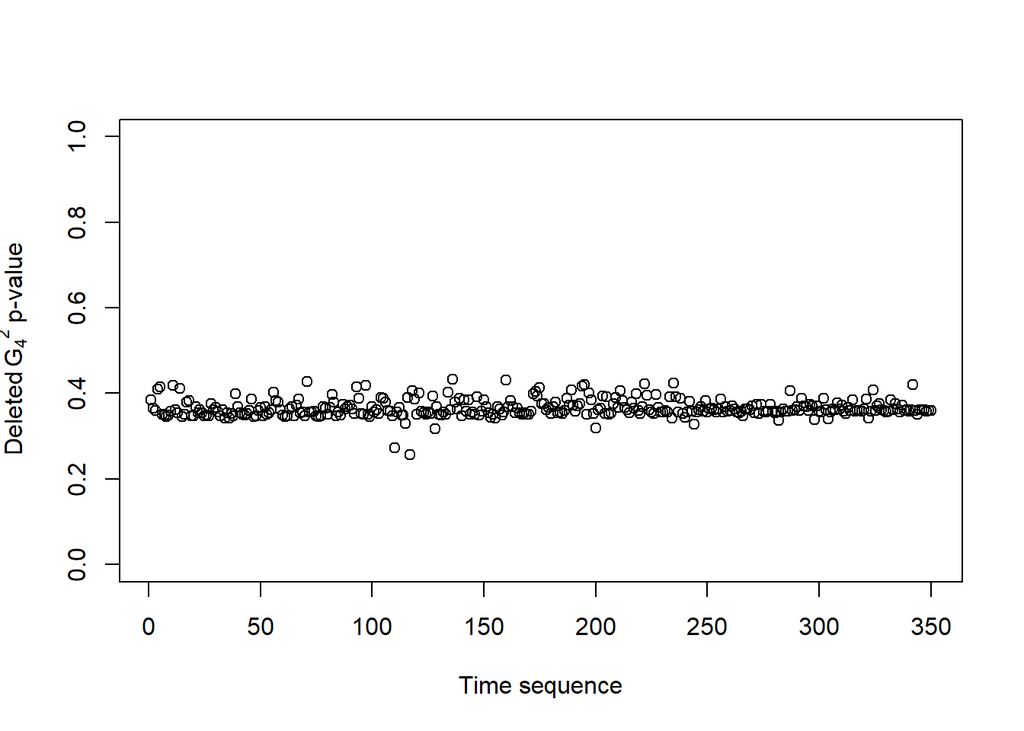

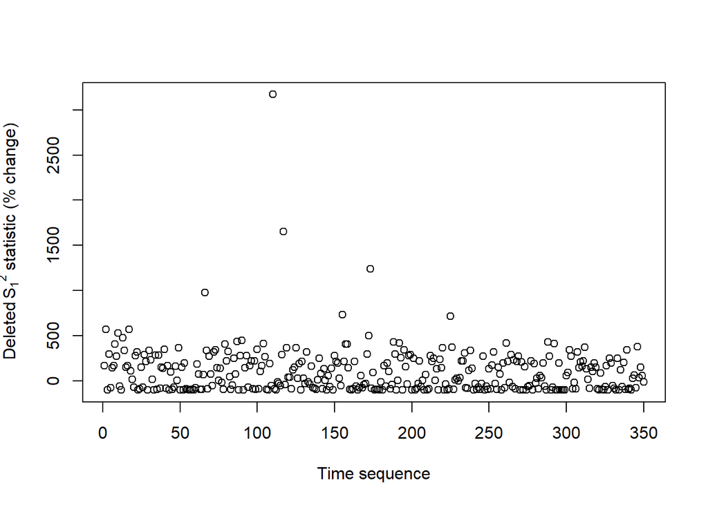

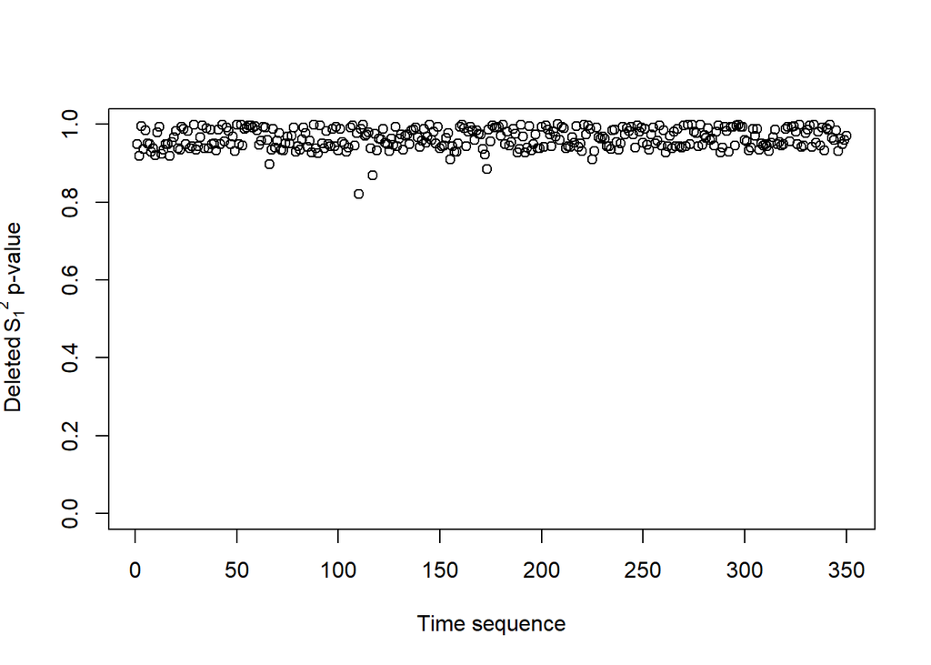

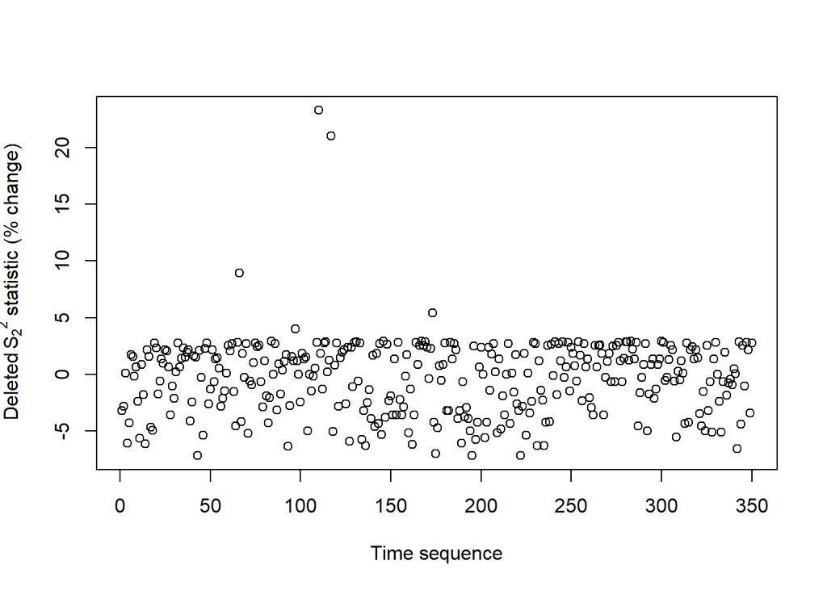

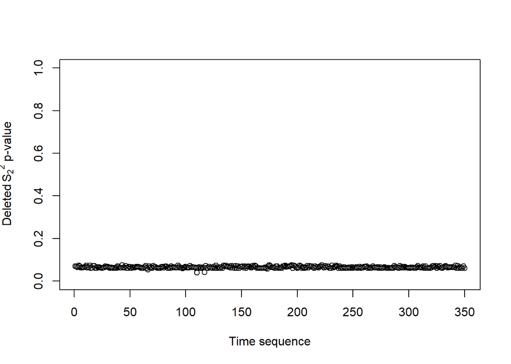

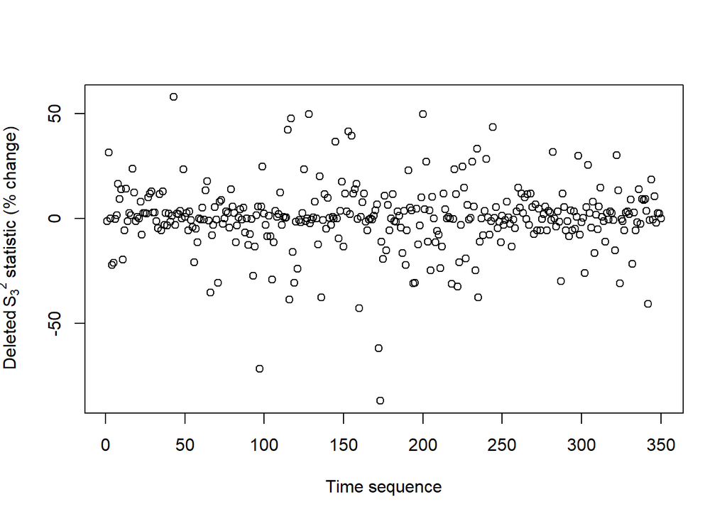

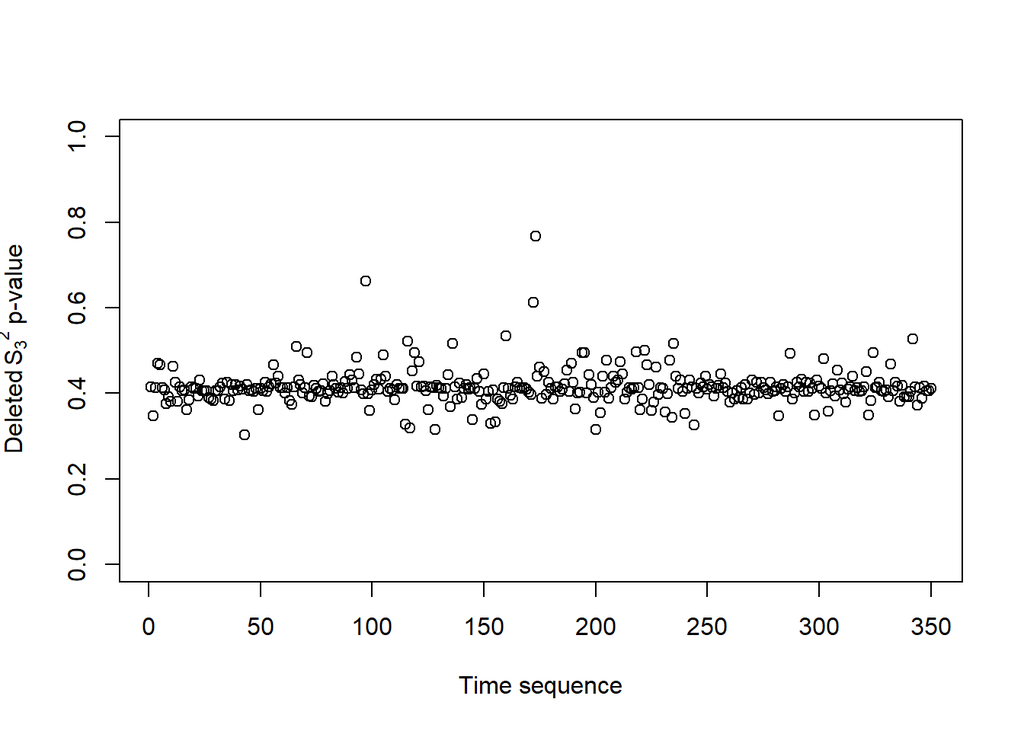

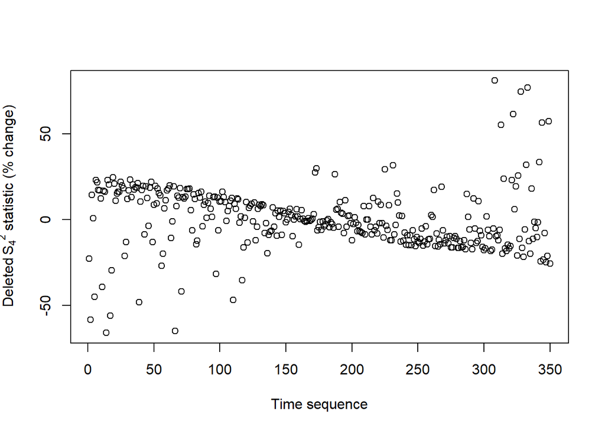

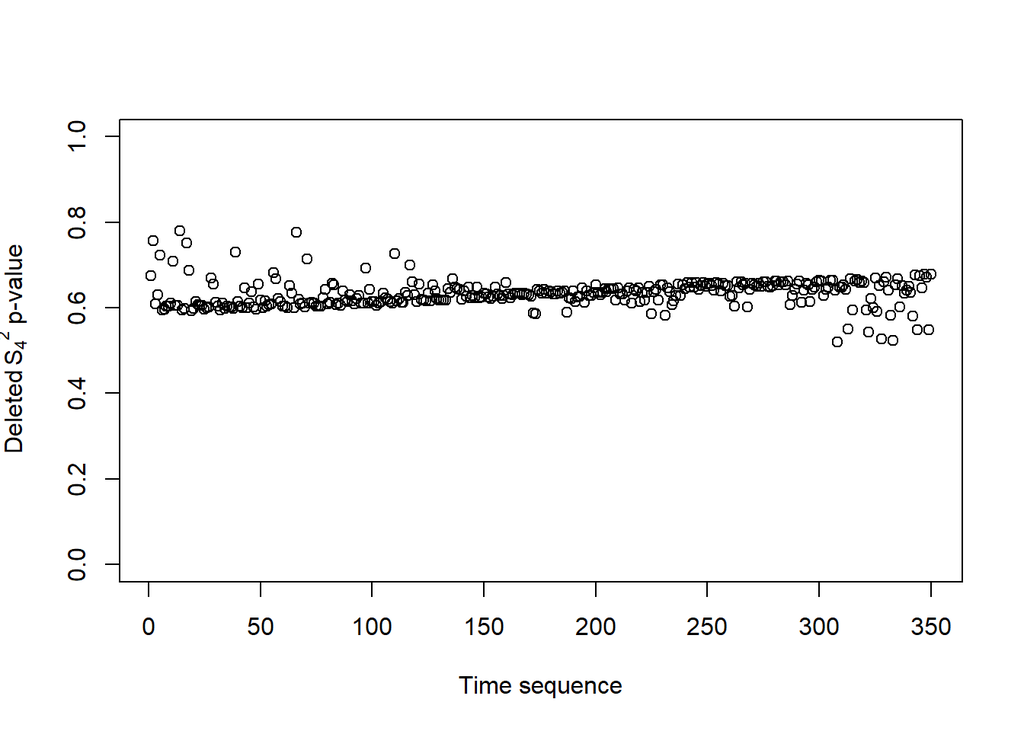

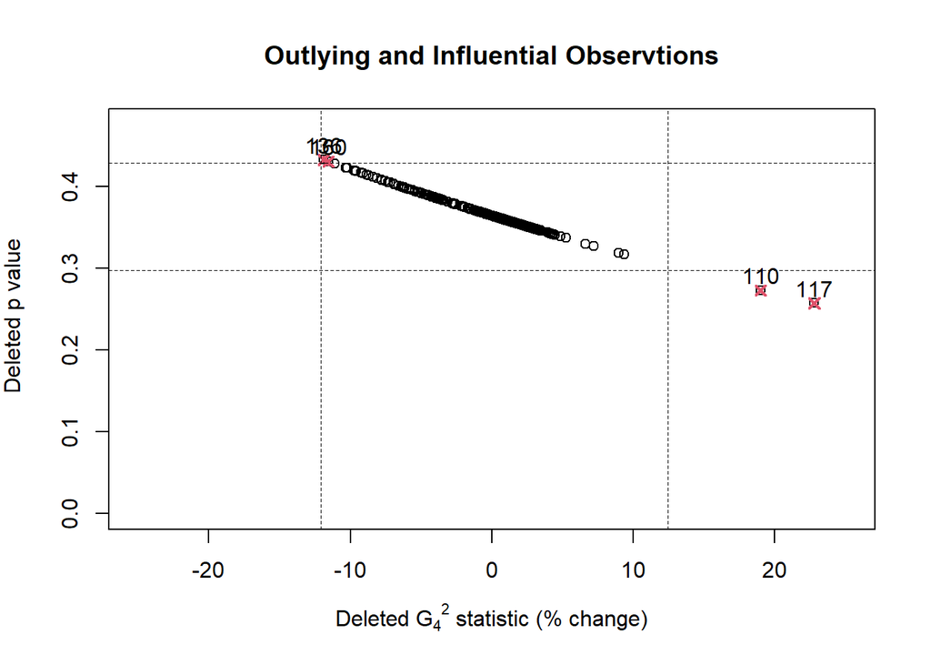

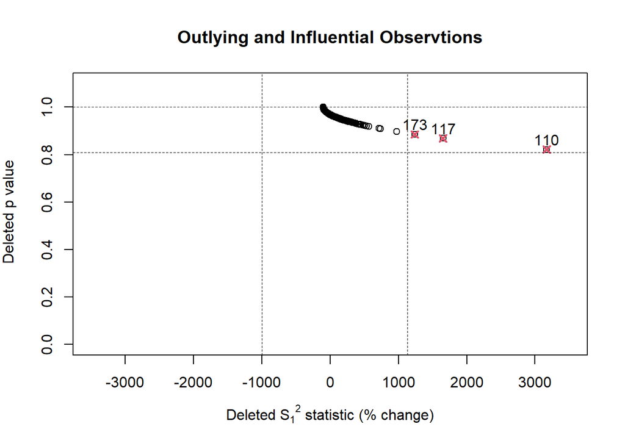

[12 more figures not shown]

[figure not shown]

```
##
## Call:
## lm(formula = nflex_3 ~ nflex_2 + nflex_5 + nflex_7, data = nflex_inv_reduct_msa)
##
## Residuals:
##     Min      1Q  Median      3Q     Max
## -3.1455 -0.9366 -0.0529  0.7007  3.3432
##
## Coefficients:
##             Estimate Std. Error t value       Pr(>|t|)
## (Intercept)  2.95511    0.45839   6.447 0.000000000384 ***
## nflex_2     -0.17835    0.07135  -2.500        0.01289 *
## nflex_5      0.15255    0.05305   2.876        0.00428 **
## nflex_7      0.23338    0.05670   4.116 0.000048303131 ***
## ---
## Signif. codes:  0 '***' 0.001 '**' 0.01 '*' 0.05 '.' 0.1 ' ' 1
##
## Residual standard error: 1.237 on 346 degrees of freedom
## Multiple R-squared:  0.1277, Adjusted R-squared:  0.1201
## F-statistic: 16.89 on 3 and 346 DF,  p-value: 0.0000000002941
##
##
## ASSESSMENT OF THE LINEAR MODEL ASSUMPTIONS
## USING THE GLOBAL TEST ON 4 DEGREES-OF-FREEDOM:
## Level of Significance =  0.05
##
## Call:
##  gvlma(x = monModel)
##
##                      Value p-value                   Decision
## Global Stat        10.5060 0.03271 Assumptions NOT satisfied!
## Skewness            5.0235 0.02501 Assumptions NOT satisfied!
## Kurtosis            1.7245 0.18911    Assumptions acceptable.
## Link Function       3.6391 0.05644    Assumptions acceptable.
## Heteroscedasticity  0.1189 0.73027    Assumptions acceptable.
##
## Global test deletion statistics.
##
## Linear Model:
##  lm(formula = nflex_3 ~ nflex_2 + nflex_5 + nflex_7, data = nflex_inv_reduct_msa)
```

[output cut: 75 more lines]

```
## 324                    20.00778                 0.03663682
## 332                    16.53017                 0.03946680
## 342                    29.86829                 0.02970905
##
##
## Unusual observations for Directional Stat4:
##     Delta Directional Stat4 (%)  Directional Stat4 p-value
## 9                     242.79587                  0.5232535
## 14                    171.98053                  0.5696319
## 36                    179.59527                  0.5642784
## 47                    113.16795                  0.6146987
## 308                   -75.86308                  0.8654941
## 332                   -77.95935                  0.8714144
## 340                   -99.27795                  0.9766280
## 342                   -93.87858                  0.9320213
```

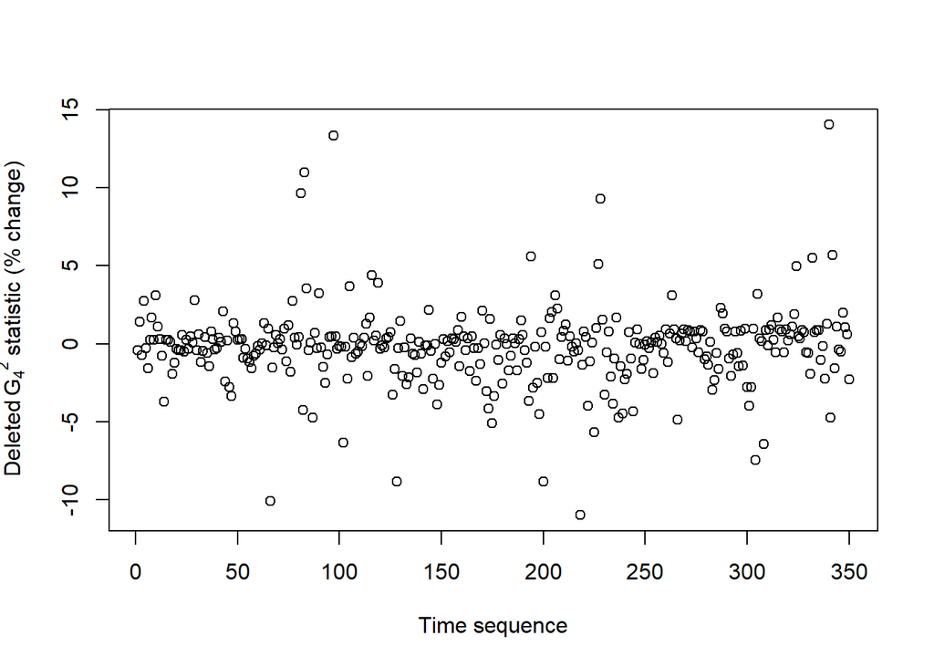

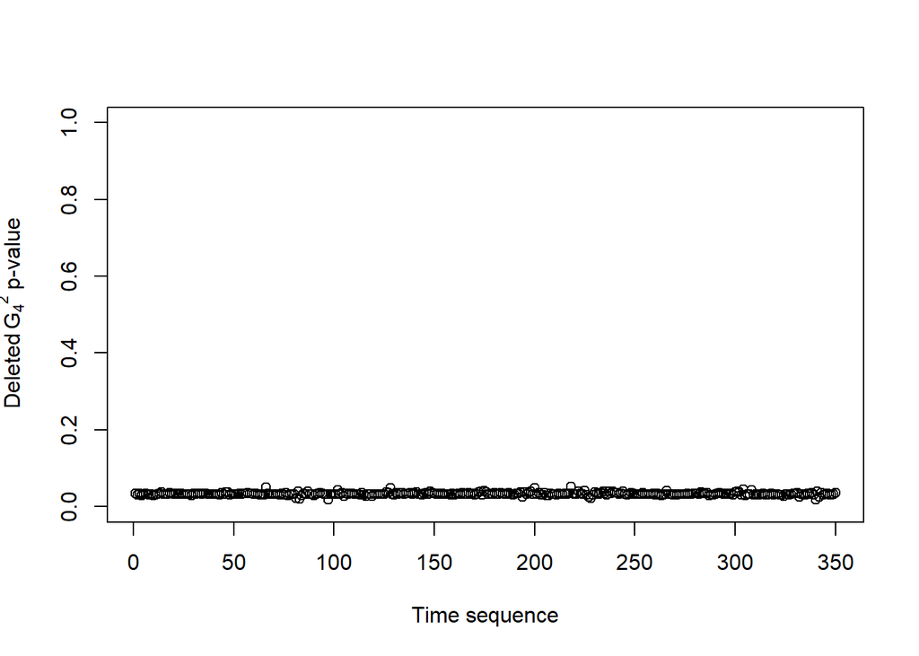

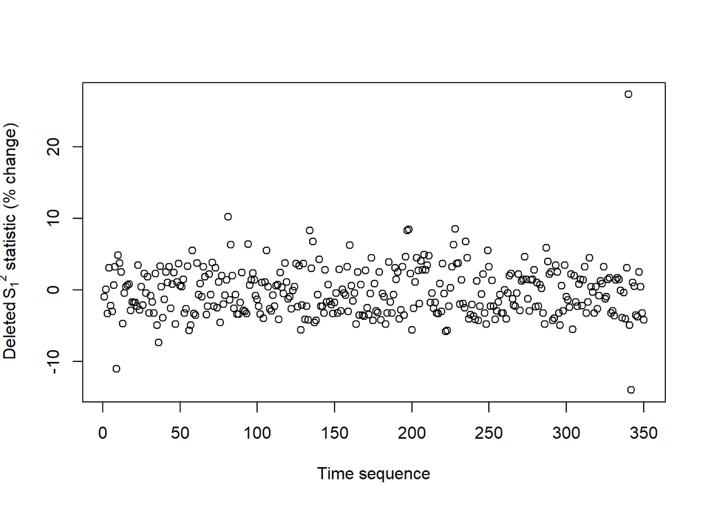

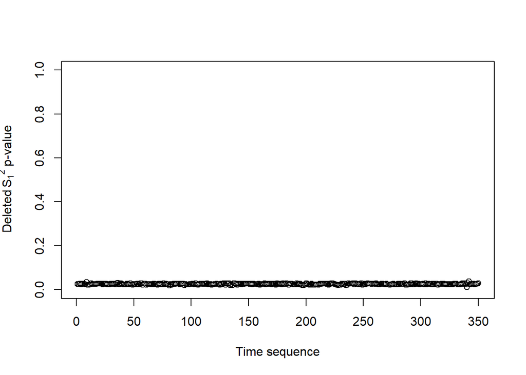

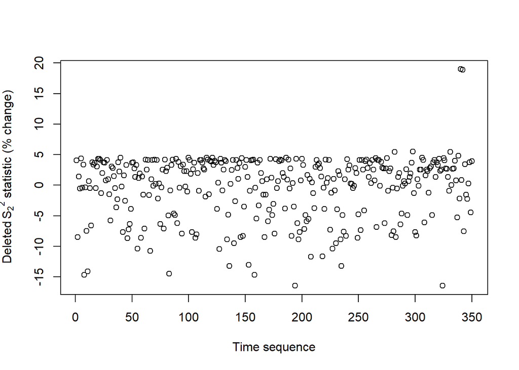

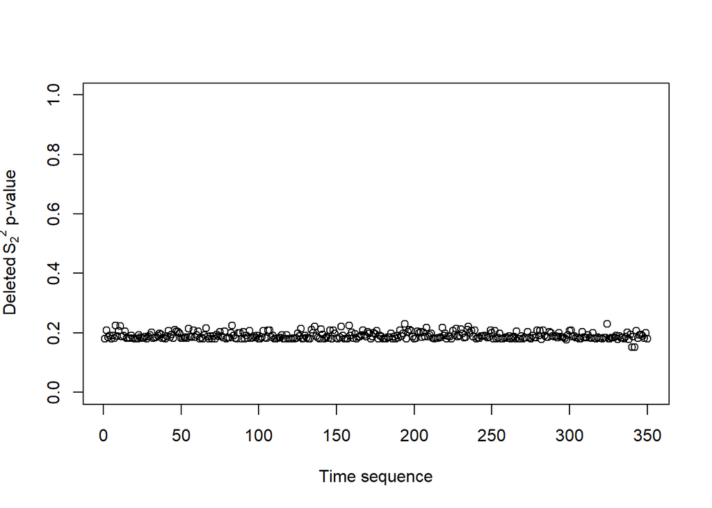

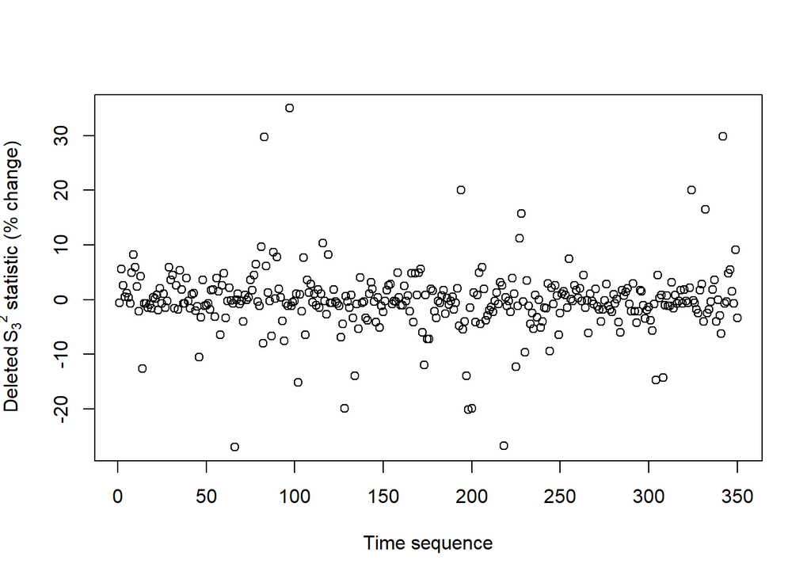

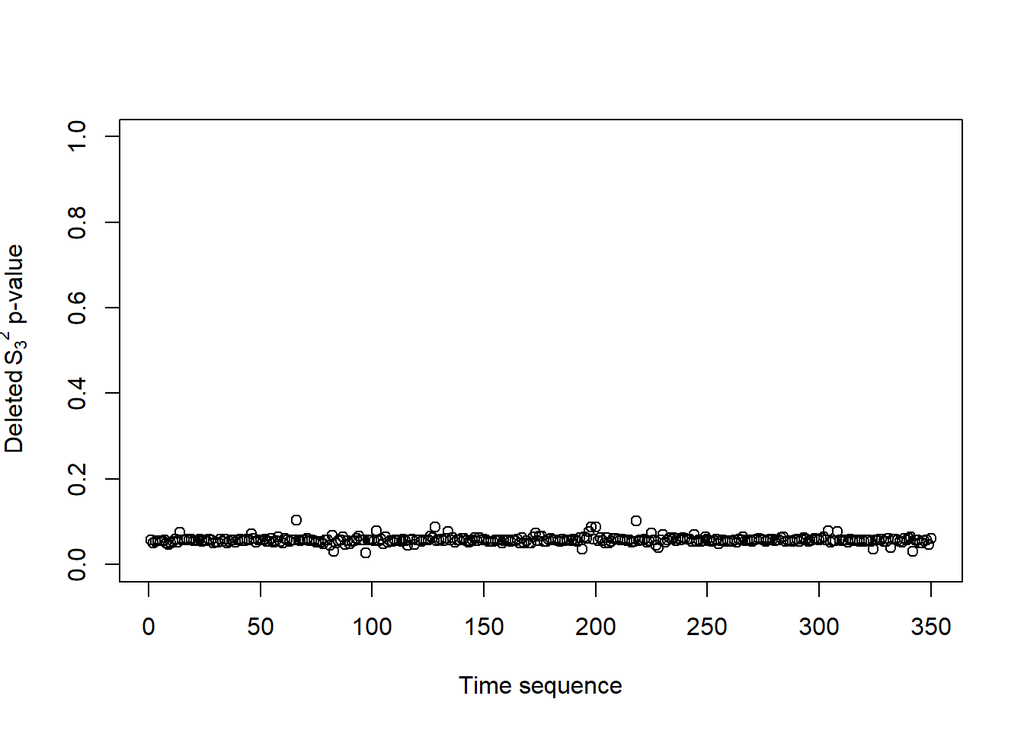

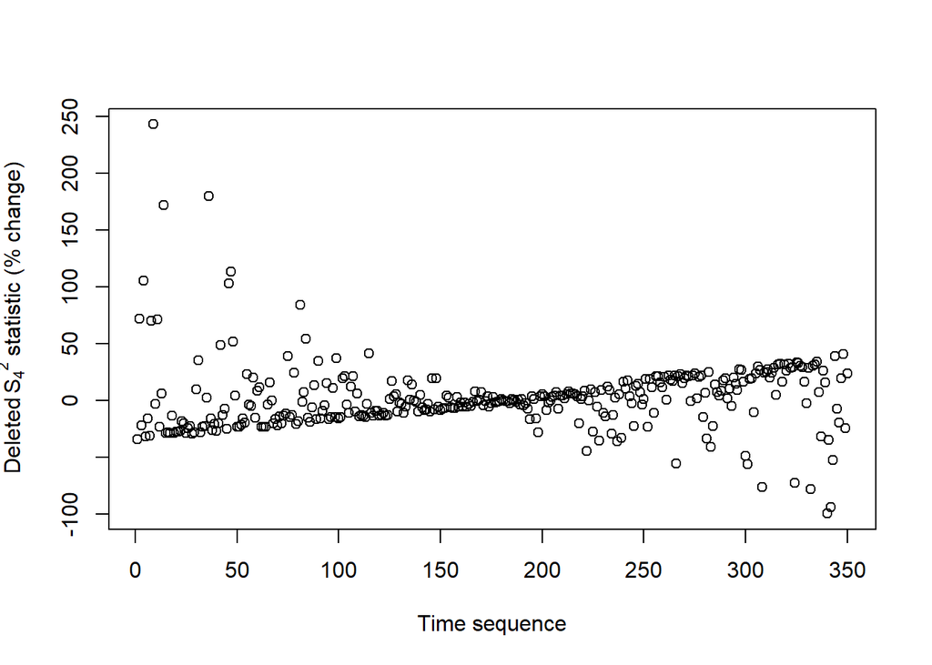

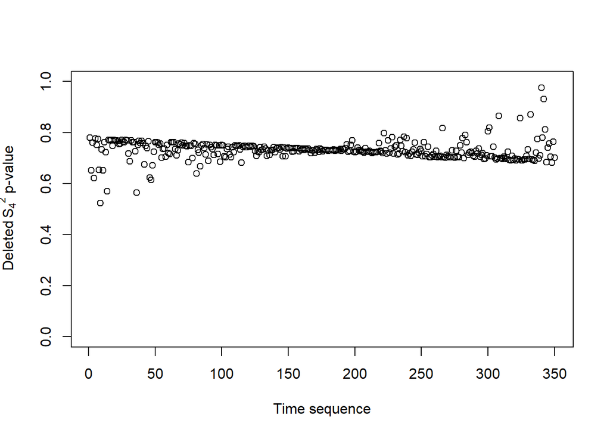

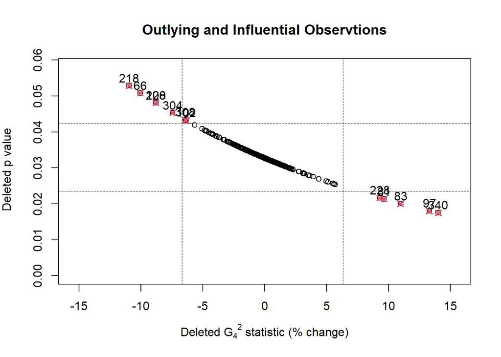

[13 more figures not shown]

```r
lm2 = lm(nflex_3~nflex_2+nflex_5+nflex_7, data=nflex_inv_reduct_msa)
ConditionRegression(lm2)
```